# Project 2 Discussion Questions

2024-04-04

Please take some time and answer the following questions. You’ll notice that some questions are more theoretical and may require you to do a little research. Feel free to also discuss with your classmates. After submission, we will provide you feedback and allow you to resubmit. We will also go through the questions together during class after resubmission.

**Methods and Quality Control** 1. Include a full methods section for this project. You may simply combine the individual methods sections you’ve written for each week.

[output not shown]

2. Examine the figure provided below:

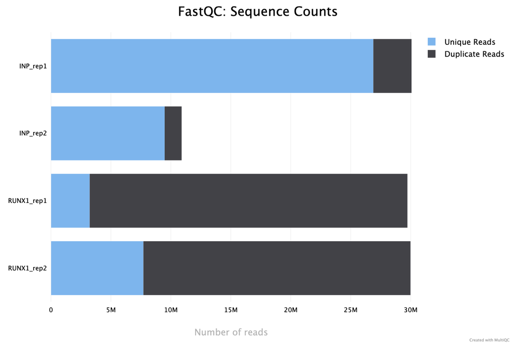

```r
knitr::include_graphics("fastqc_sequence_counts_plot.png")
```

Notice the duplication rates between the IP (Runx1) and Input control samples. Provide an explanation for why they are so different. Also make sure to note whether you think this represents an issue with the dataset, and if so, why?

[output not shown]

2. Examine the figure provided below:

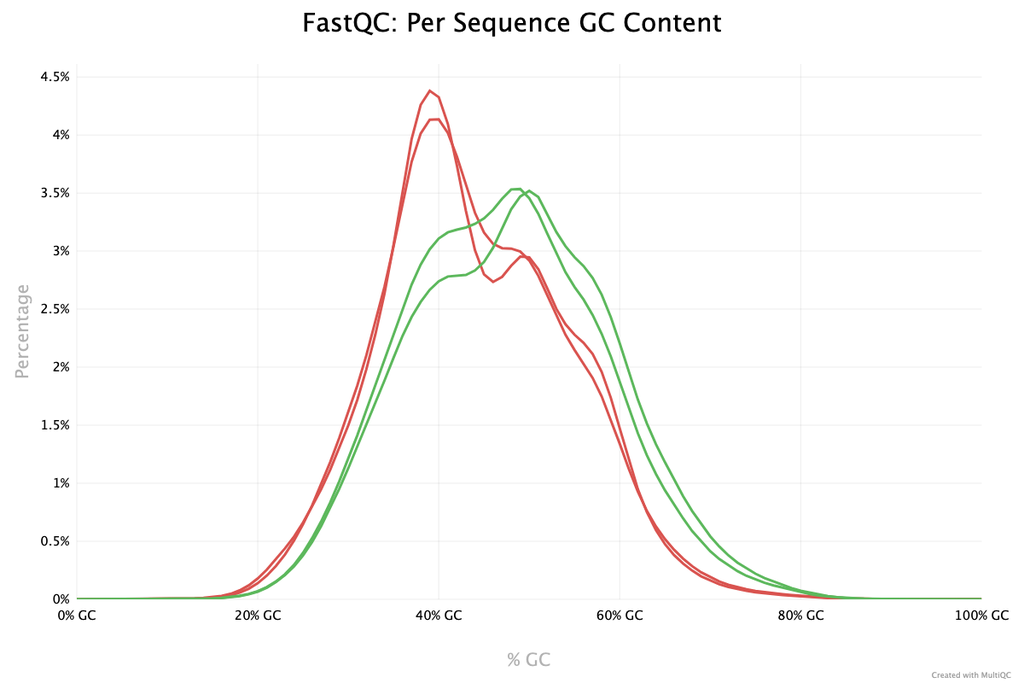

```r
knitr::include_graphics("fastqc_per_sequence_gc_content_plot.png")
```

Consider the GC plot for the IP and Input control samples. The two input samples are represented by the red distributions, and the IP samples are the green distributions. Why do you think we see a difference in the GC distribution between our IP and Input control samples? Also make sure to note whether you think this represents an issue with the dataset and if so, why?

[output not shown]

**Thought Questions on Publication** The following questions will reference the original publication, which can be found here: https://www.ncbi.nlm.nih.gov/pmc/articles/PMC5071180/ 3. First, please report the following results: A. How many peaks were called in each of the biological replicates in your results?

```
Replicate 1 has 106072 peaks and replicate 2 has 50952 peaks.
```

B. How many “reproducible” peaks did you end up with after applying your bedtools intersect strategy on the two replicate peak sets?

```
There were 10924 reproducible peaks.
```

C. How many “reproducible” peaks remained after filtering out any peaks found in the hg38 blacklisted regions?

```
There were 10785 filtered reproducible peaks.
```

Consider Supplementary Figure S2C, do you obtain the same number of Runx1 peaks for each replicate experiment? Do you obtain the same number of reproducible peaks? If not, provide at least three reasons why your results differ.

[output not shown]

4. Consider figure 2a, notice that around 1/3 of all of their reported reproducible peaks are annotated to intergenic regions (regions of the genome not associated with any known genes). Propose at least two experiments (or sets of experiments) that would help you begin to understand whether these peaks are biologically relevant.

[output not shown]

5. Consider figure 2f, note that many of the genes that are differentially expressed upon Runx1 knockdown do **not** have a proximal Runx1 binding peak. Provide at least three reasons for why this might be the case.

[output not shown]

**Reporting your results** For the next section, please include the requested figures you generated from your workflow. For results that are not already a plot / image file, take a quick screenshot and include it here. Make sure you push these images to this github classroom repo and include the name / path in the knitr::include_graphics() function provided.

Please display your correlation plot displaying the overall similarity between your sample files based on the read coverage scores across genomic regions:

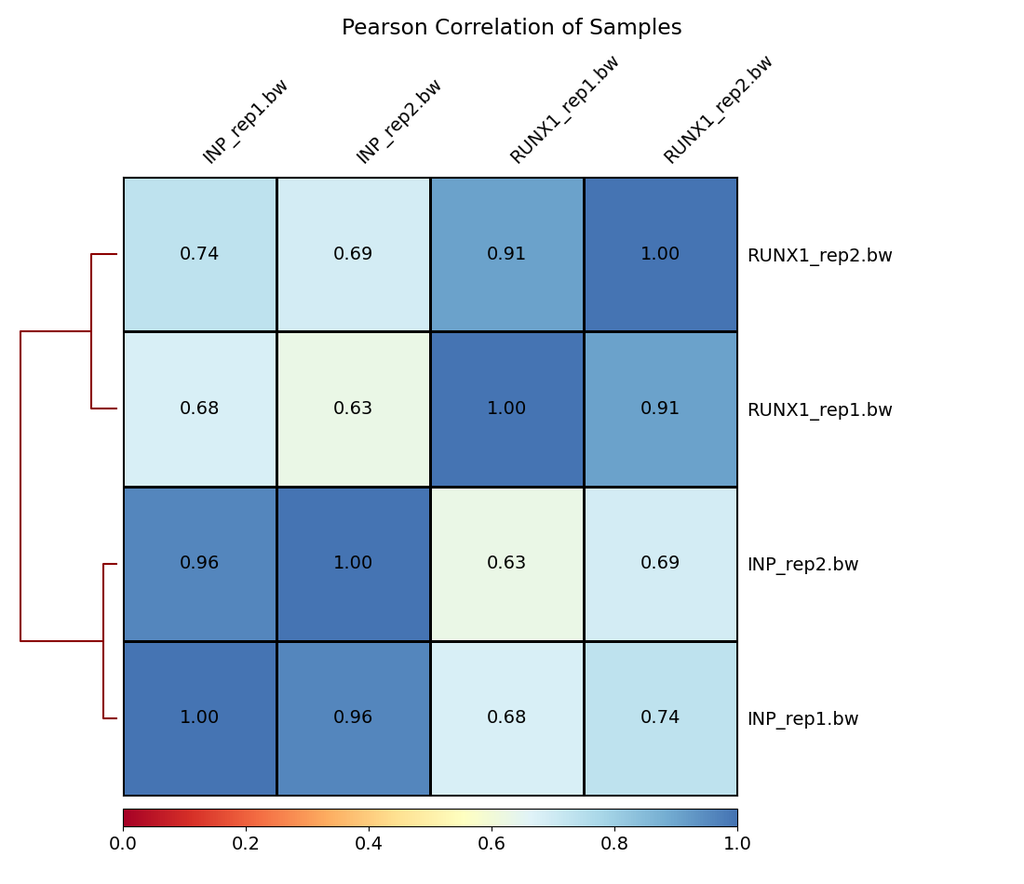

```r
knitr::include_graphics("correlation_matrix.png")
```

Please include a screenshot of the top ten results from the knownResults output from motif finding with HOMER findMotifsGenome:

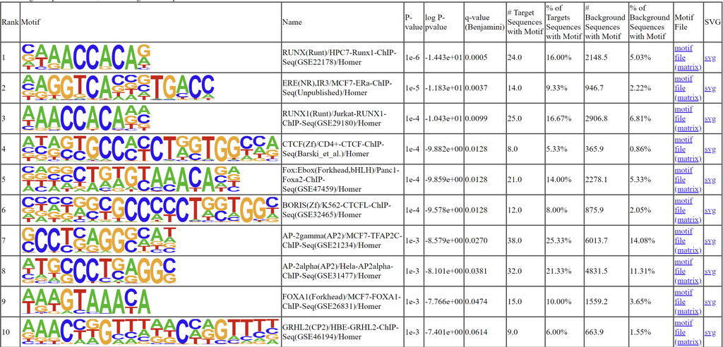

```r
knitr::include_graphics("knownResults_top10.png")
```

Please include the signal coverage plot you generated in week 4. This is the output of plotProfile that shows the density of Runx1 binding across all of the hg38 gene bodies. You only need to show one representative plot:

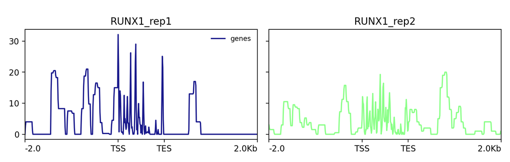

```r
knitr::include_graphics("RUNX1_plot.png")
```

Please include one of the screenshots of the genome browser view of either the MALAT1 or NEAT1 locus with your bigWig files and BED file. You only need to include one:

[figure not shown]

```r
knitr::include_graphics("MALAT1.png")
```